# Внешний курс. Блок 2 Защита ПК/телефона

Основы информационной безопасности

Луангсуваннавонг Сайпхачан

# Информация

## Докладчик

- Луангсуваннавонг Сайпхачан
- студент группы НКАбд-01-24
- Российский университет дружбы народов им. П. Лумумбы
- https://github.com/sayprachanh-lsvnv

## Цель работы

Выполнение контрольных заданий второго блока внешнего курса “Основы Кибербезопасности”

# Выполнение заданий блока “Защита ПК/телефона”

## Шифрование диска

Полнодисковое шифрование (BitLocker, LUKS) шифрует загрузочный сектор и требует предзагрузочной аутентификации.

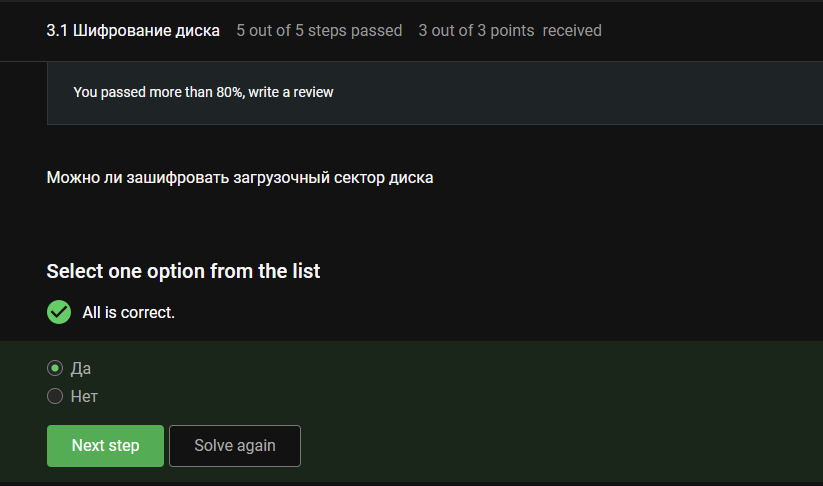

Шифрование диска

## Шифрование диска

Дисковое шифрование использует симметричные шифры (AES) — один ключ для шифрования и дешифрования (быстрее для больших объёмов).

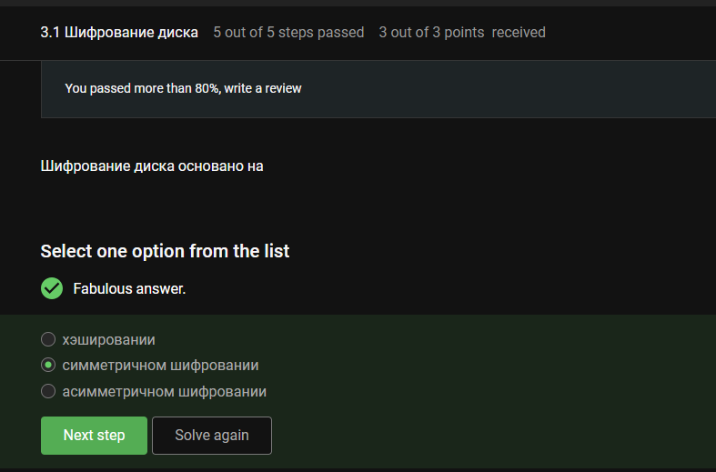

Шифрование диска

## Шифрование диска

Дисковая утилита (Disk Utility) — управление дисками в macOS, не специализированный инструмент полнодискового шифрования (VeraCrypt, BitLocker). Wireshark не относится к этому.

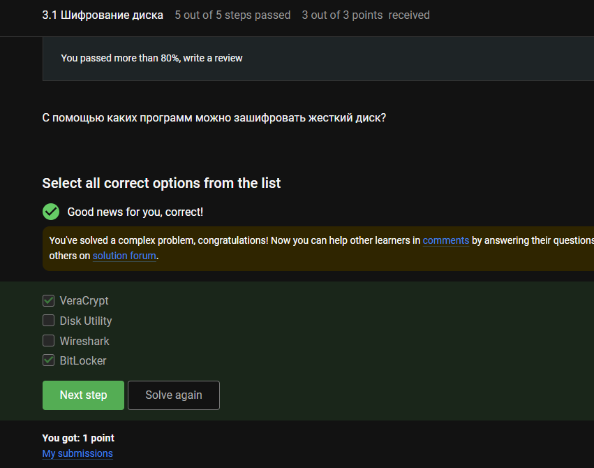

Шифрование диска

## Пароли

Ответ: `UQr9@j4!S$` (заглавные/строчные буквы, цифры, символы, достаточно длинный). Другие варианты предсказуемы или словарные.

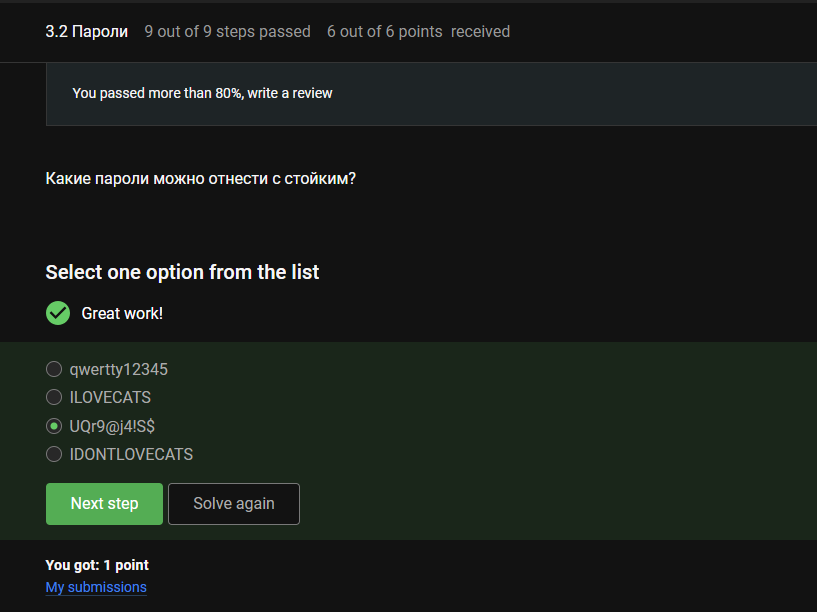

Информация о пароле

## Пароли

Менеджеры паролей хранят пароли в зашифрованном виде, требуют один мастер-пароль. Другие варианты небезопасны.

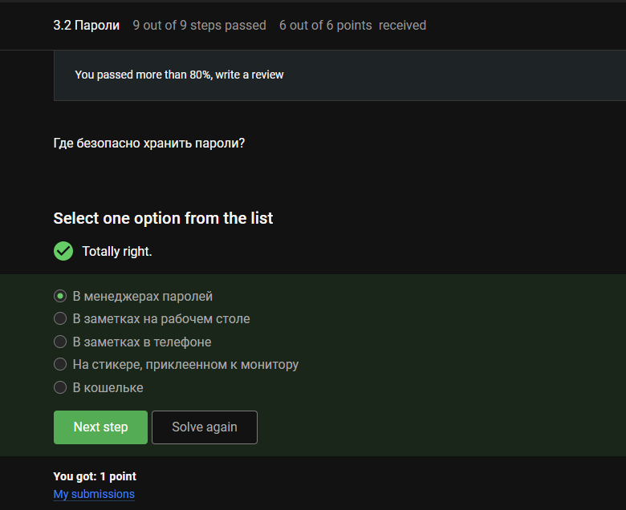

Информация о пароле

## Пароли

CAPTCHA отличает людей от ботов, предотвращает автоматизированные атаки (перебор паролей, спам).

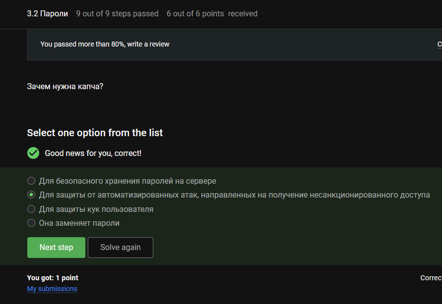

CAPTCHA

## Пароли

Хеширование преобразует пароли в хеши фиксированной длины — при утечке БД оригинальные пароли не раскрываются.

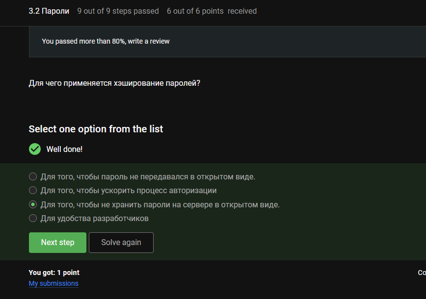

Хеширование

## Пароли

Соль (salt) делает каждый хеш пароля уникальным, предотвращает атаки с радужными таблицами.

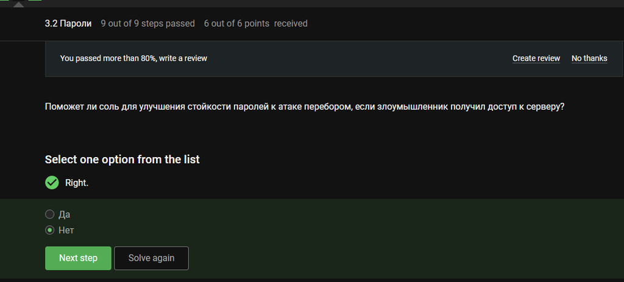

Хеширование

## Пароли

Разные пароли — ограничивают ущерб от утечки. Периодическая смена — сокращает окно использования скомпрометированных данных. Сложные/длинные пароли — делают перебор непрактичным. CAPTCHA — блокирует автоматизированные атаки.

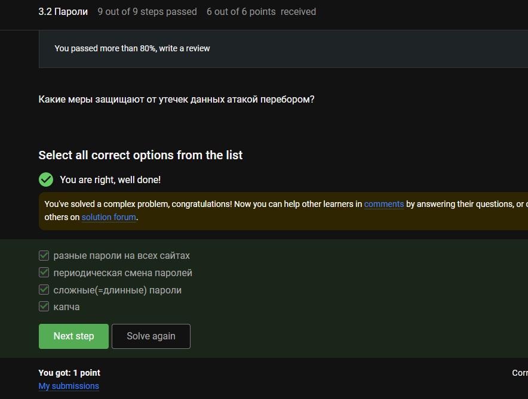

Защита паролем

## Фишинг

wix.ru — не официальный домен Сбербанка (должен быть sberbank.ru). ucoz.ru — не официальный домен Яндекса (должен быть yandex.ru). Ссылки на Google и Mail.ru используют официальные домены.

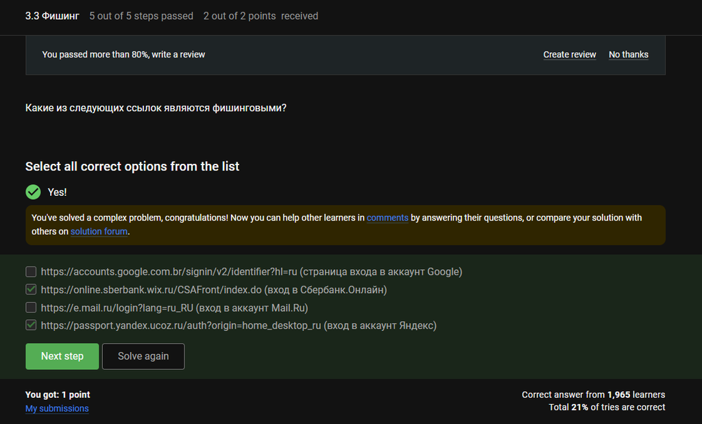

Фишинговая ссылка

## Фишинг

Злоумышленники могут подделать email-адреса или взломать аккаунт друга для фишинговых писем.

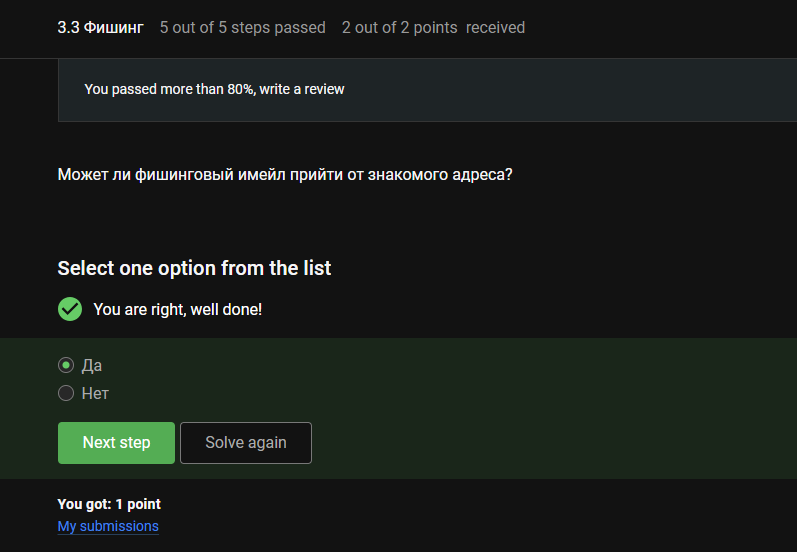

Возможность фишинга

## Вирусы. Примеры

Подделка электронной почты (email spoofing) подделывает адрес «Отправитель», чтобы обмануть получателя.

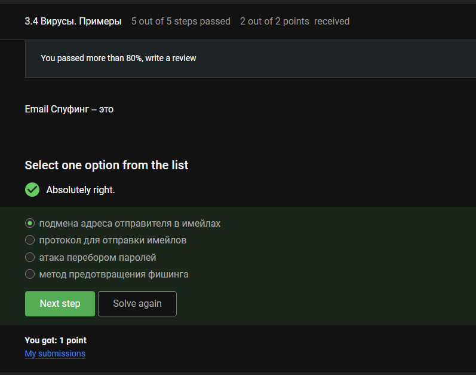

Подделка электронной почты

## Вирусы. Примеры

Троян (Trojan) маскируется под легальное ПО, чтобы обманом заставить пользователя запустить его.

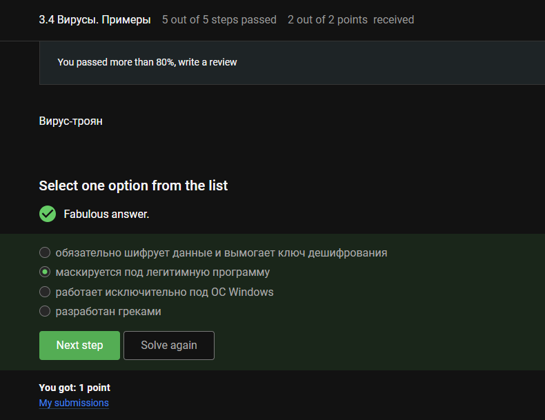

Trojan

## Безопасность мессенджеров

В протоколе Signal ключ шифрования устанавливается при создании сессии, когда отправитель генерирует первое сообщение (согласование ключей X3DH).

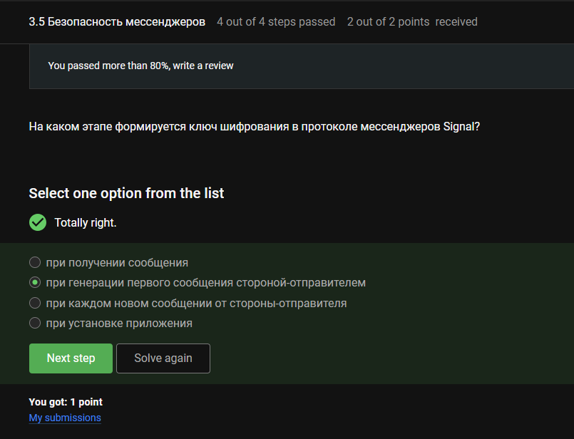

Шифрование ключей

## Безопасность мессенджеров

Сквозное шифрование (end-to-end encryption) — только отправитель и получатель читают сообщения; серверы видят только зашифрованный текст.

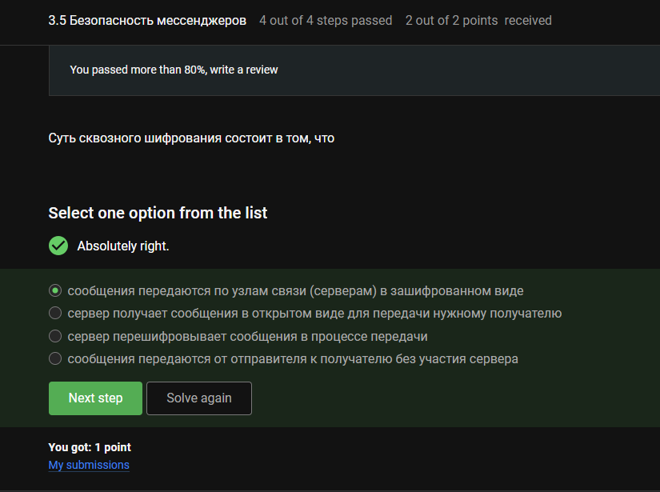

Сквозное шифрование

# Выводы

Во время этого блока я узнал о правилах хранения паролей, основной информации о вирусах и методе фишинга